# Introduction to R

## Example with Iris

The *iris* flower data set is included in R. It is a data frame with 150 cases (rows) and 5 variables (columns) named Sepal.Length, Sepal.Width, Petal.Length, Petal.Width, and Species.

First, load iris data to the current workspace

```r
data(iris)
```

### What is in the dataset?

You can use `head()` or `tail` to print the first or last few rows of a dataset:

```r
head(iris)
```

```
##   Sepal.Length Sepal.Width Petal.Length Petal.Width Species
## 1          5.1         3.5          1.4         0.2  setosa
## 2          4.9         3.0          1.4         0.2  setosa
## 3          4.7         3.2          1.3         0.2  setosa
## 4          4.6         3.1          1.5         0.2  setosa
## 5          5.0         3.6          1.4         0.2  setosa
## 6          5.4         3.9          1.7         0.4  setosa
```

Check dimensionality, the dataset has 150 rows(observations) and 5 columns (variables)

```r
dim(iris)
```

```
## [1] 150   5
```

Another way to get the dim is to use ncol or nrow:

```r
ncol(iris)
```

```
## [1] 5
```

```r
nrow(iris)
```

```
## [1] 150
```

Variable names or column names

```r
names(iris)
```

```
## [1] "Sepal.Length" "Sepal.Width"  "Petal.Length" "Petal.Width"
## [5] "Species"
```

You can also use this command

```r
colnames(iris)
```

Structure of the dataframe, note that the difference between *num* and *Factor*

```r
str(iris)
```

```
## 'data.frame':    150 obs. of  5 variables:
##  $ Sepal.Length: num  5.1 4.9 4.7 4.6 5 5.4 4.6 5 4.4 4.9 ...
##  $ Sepal.Width : num  3.5 3 3.2 3.1 3.6 3.9 3.4 3.4 2.9 3.1 ...
##  $ Petal.Length: num  1.4 1.4 1.3 1.5 1.4 1.7 1.4 1.5 1.4 1.5 ...
##  $ Petal.Width : num  0.2 0.2 0.2 0.2 0.2 0.4 0.3 0.2 0.2 0.1 ...
##  $ Species     : Factor w/ 3 levels "setosa","versicolor",..: 1 1 1 1 1 1 1 1 1 1 ...
```

By default, R treat strings as factors (or categorical variables), in many situations (for example, building a regression model) this is what you want because R can automatically create “dummy variables” from the factors. However when merging data from different sources this can cause errors. In this case you can use `stringsAsFactors = FALSE` option in `read.table`.

### Subsetting the Dataset I: Numerical Index and Variable Names

Get the first 5 rows/obs

```r
iris[1:5,]
```

```
##   Sepal.Length Sepal.Width Petal.Length Petal.Width Species
## 1          5.1         3.5          1.4         0.2  setosa
## 2          4.9         3.0          1.4         0.2  setosa
## 3          4.7         3.2          1.3         0.2  setosa
## 4          4.6         3.1          1.5         0.2  setosa
## 5          5.0         3.6          1.4         0.2  setosa
```

Get Sepal.Length of the first 10 rows

```r
iris[1:10, "Sepal.Length"]
```

```
##  [1] 5.1 4.9 4.7 4.6 5.0 5.4 4.6 5.0 4.4 4.9
```

or alternatively

```r
iris$Sepal.Length[1:10]
```

```
##  [1] 5.1 4.9 4.7 4.6 5.0 5.4 4.6 5.0 4.4 4.9
```

or you can use the column index instead of variable names. Since Sepal.Length is the first column:

```r
iris[1:10, 1]
```

```
##  [1] 5.1 4.9 4.7 4.6 5.0 5.4 4.6 5.0 4.4 4.9
```

### Subsetting the Dataset II: Logical Conditions

There are 3 ways to get subsets of data that satisfy certain logical conditions. These kind of operations are called filtering in Excel. Knowing any one of these well is enough. Do not worry about memorizing the syntax, you can always look them up.

Suppose we want to get the **observations that have Sepal.Length > 5 and Sepal.Width > 4**.

#### Logical operators

!= not equal to

== equal to

& and

#### Use subset function

```r
subset(x = iris, subset = Sepal.Length > 5 & Sepal.Width > 4)
```

You can omit the x = and subset = part

```r
subset(iris, Sepal.Length > 5 & Sepal.Width > 4)
```

#### Use logical vectors

```r
iris[(iris$Sepal.Length > 5 & iris$Sepal.Width > 4), ]
```

```
##    Sepal.Length Sepal.Width Petal.Length Petal.Width Species
## 16          5.7         4.4          1.5         0.4  setosa
## 33          5.2         4.1          1.5         0.1  setosa
## 34          5.5         4.2          1.4         0.2  setosa
```

#### Use SQL statement

```r
install.packages('sqldf')
library(sqldf)
sqldf('select * from iris where `Sepal.Length` > 5 and `Sepal.Width` > 4')
```

In earlier version of sqldf all dots(.) in variable names need to be changed to underscores(_).

### Subsetting the Dataset III: Random Sample

The following code random sample (without replacement) 90% of the original dataset and assgin them to a new variable *iris_sample*.

```r
iris_sample = iris[sample(x = nrow(iris), size = nrow(iris)*0.90),]
```

### Subsetting the Dataset IV: dplyr (**tidyverse**)

The `dplyr` package provides more convinient ways for generating random samples. You can take a fixed number of samples using `sample_n()` or a fraction using `sample_frac()` as follows

```r
install.packages('dplyr')
library(dplyr)
iris_sample = sample_frac(iris, 0.9)
# using dplyr for logical subsetting
filter(iris, Sepal.Length> 3, Sepal.Width > 3)
```

Chaining in dplyr:

```r
iris %>%
  filter(Sepal.Length> 3, Sepal.Width > 3) %>%
  select(Sepal.Length, Sepal.Width, Species) %>%
  mutate(log_sepal_length = log(Sepal.Length), log_sepal_width = log(Sepal.Width)) %>%
  summarise(avg_log_sepal_length = mean(log_sepal_length), avg_log_sepal_width = mean(log_sepal_width))
```

I recommend you to go through the [`dplyr` tutorial](https://cran.rstudio.com/web/packages/dplyr/vignettes/introduction.html) and [lubridate tutorial](http://vita.had.co.nz/papers/lubridate.html). They make common data manipulation tasks and dealing with time-date much easier in R.

### Sorting

Sorting by one or more variables is a common operation that you can do with datasets. With RStudio version 0.99+, you can sort a dataset when viewing it by clicking column header.

To do it with code, let’s suppose that you would like to find the top 5 rows in `iris` dataset with largest `Sepal.Length`.

```r
iris[order(iris$Sepal.Length, decreasing = TRUE)[1:5], ]
```

```
##     Sepal.Length Sepal.Width Petal.Length Petal.Width   Species
## 132          7.9         3.8          6.4         2.0 virginica
## 118          7.7         3.8          6.7         2.2 virginica
## 119          7.7         2.6          6.9         2.3 virginica
## 123          7.7         2.8          6.7         2.0 virginica
## 136          7.7         3.0          6.1         2.3 virginica
```

The syntax is cleaner with the `arrange()` function in the `dplyr` package (**tidyverse**):

```r
arrange(iris, desc(Sepal.Length))[1:5, ]
```

### Summary Statistics and Plots

Summary statistics of every variable

```r
summary(iris)
```

```
##   Sepal.Length    Sepal.Width     Petal.Length    Petal.Width
##  Min.   :4.300   Min.   :2.000   Min.   :1.000   Min.   :0.100
##  1st Qu.:5.100   1st Qu.:2.800   1st Qu.:1.600   1st Qu.:0.300
##  Median :5.800   Median :3.000   Median :4.350   Median :1.300
##  Mean   :5.843   Mean   :3.057   Mean   :3.758   Mean   :1.199
##  3rd Qu.:6.400   3rd Qu.:3.300   3rd Qu.:5.100   3rd Qu.:1.800
##  Max.   :7.900   Max.   :4.400   Max.   :6.900   Max.   :2.500
##        Species
##  setosa    :50
##  versicolor:50
##  virginica :50
##
##
##
```

Frequency of species

```r
table(iris$Species)
```

```
##
##     setosa versicolor  virginica
##         50         50         50
```

Pie Chart

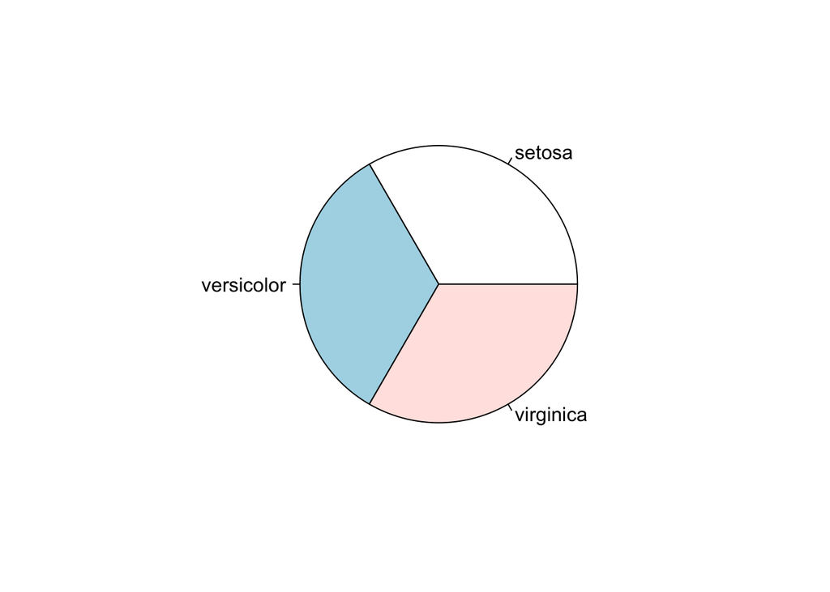

```r
pie(table(iris$Species))
```

Plot histogram of Sepal.length

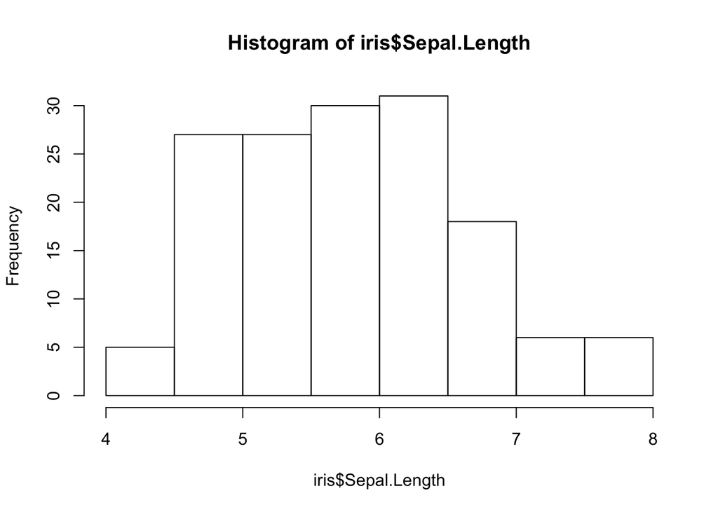

```r
hist(iris$Sepal.Length)
```

The go-to plotting package for many of us working with R is [`ggplot2`](http://ggplot2.org/). Combined with [`shiny`](http://shiny.rstudio.com/) we can build interactive plots. Read a related book or tutorial if you are interested.

### Summerizing by group

Suppose we want to know the average Sepal length by species

```r
library(sqldf)
sqldf('select avg(`Sepal.Length`) as mean_sepal_length from iris group by Species')
```

Use dplyr (**tidyverse**)

```r
library(dplyr)
iris %>% group_by(Species) %>% summarise(mean_sepal_length = mean(Sepal.Length))
```

What if we want to calculate the geometric mean (or any other defined summarization function) of the sepal length by species?

```r
geometric_mean = function(x){
  return(exp(mean(log(x))))
}
iris %>% group_by(Species) %>% summarise(mean_sepal_length = geometric_mean(Sepal.Length))
```

### Organizing your computations

1. R has a “current directory” (Working Directory). To set Working Directory in RStudio: Session -> Set Working Directory.
2. Your objects (loaded datasets, variables, functions, etc.) are contained in your “current workspace”, which can be saved any time. In Rstudio: Session -> Load Workspace/Save Workspace As.
3. Keep it tidy! Keep separate projects (code, data files) in separate workspaces/directories.

### Help

1. Use *help(mean)* or *?mean* to find help documents for the function *mean*.
2. In Rstudio, pressing tab after a function name gives help about the arguments
3. A google search will probably answer most of your questions.
4. Where to ask questions?
- Stackoverflow (a more friendly place): http://stackoverflow.com/questions/tagged/r
- R Help Mailing List: http://r.789695.n4.nabble.com/R-help-f789696.html

Note: Part of this handout is built upon Clarkson University’s R Tutorial [1](http://www.cyclismo.org/tutorial/R/) and Dr.Yan Yu’s slides.